# Introduction

# 2. Natural Language Processing

[figure not shown]

In almost all Natural Language Processing (the field that explores interactions between a computer and human languages) tasks that you will come across (be it topic modelling, or word clustering or document-text classification etc), one will generally always have to undergo these few pre-processing steps to convert the input raw text into a form that is readable by your model and the machine. You certainly can't expect to feed a Random Forest model a paragraph of words and expect it to immediately predict which author that paragraph came from. Behind the scenes, text pre-processing can be boiled down to these few simple steps:

1. **Tokenization** - Segregation of the text into its individual constitutent words.
2. **Stopwords** - Throw away any words that occur too frequently as its frequency of occurrence will not be useful in helping detecting relevant texts. (as an aside also consider throwing away words that occur very infrequently).
3. **Stemming** - combine variants of words into a single parent word that still conveys the same meaning
4. **Vectorization** - Converting text into vector format. One of the simplest is the famous bag-of-words approach, where you create a matrix (for each document or text in the corpus). In the simplest form, this matrix stores word frequencies (word counts) and is oft referred to as vectorization of the raw text.

**Natural Language Toolkit (NLTK)**: To make our Natural Language Processing endeavours more convenient, let me introduce to you one of the most handy toolkits that on NLP - the Natural Language Toolkit, also more commonly referred to as the [NLTK](http://www.nltk.org/) module. To import the toolkit, it is as easier as:

```python
import nltk
```

## 2a. Tokenization

Here we split the first sentence of the text in the training data just on a space as follows:

```python
# Storing the first text element as a string
first_text = train.text.values[0]
print(first_text)
print("="*90)
print(first_text.split(" "))
```

```
This process, however, afforded me no means of ascertaining the dimensions of my dungeon; as I might make its circuit, and return to the point whence I set out, without being aware of the fact; so perfectly uniform seemed the wall.
==========================================================================================
['This', 'process,', 'however,', 'afforded', 'me', 'no', 'means', 'of', 'ascertaining', 'the', 'dimensions', 'of', 'my', 'dungeon;', 'as', 'I', 'might', 'make', 'its', 'circuit,', 'and', 'return', 'to', 'the', 'point', 'whence', 'I', 'set', 'out,', 'without', 'being', 'aware', 'of', 'the', 'fact;', …
```

However as you can see from this first attempt at tokenization, the segregation of the sentence into its individual elements (or terms) is not entirely accurate. As an example, look at the second element of the list which contains the term "process,". The punctuation mark (comma) has also been included and is being treated along with the word "process" as a term in itself. Ideally we would like the comma and the word to be in two different and separate elements of the list. Trying to do this with pure python list operations will be quite complex so this is where the NLTK library comes into play. There is a convenient method "word_tokenize( )" (TreebankWord tokenizer) which strips out singular words as well as punctuations into separate elements automatically as follows:

```python
first_text_list = nltk.word_tokenize(first_text)
print(first_text_list)
```

```
['This', 'process', ',', 'however', ',', 'afforded', 'me', 'no', 'means', 'of', 'ascertaining', 'the', 'dimensions', 'of', 'my', 'dungeon', ';', 'as', 'I', 'might', 'make', 'its', 'circuit', ',', 'and', 'return', 'to', 'the', 'point', 'whence', 'I', 'set', 'out', ',', 'without', 'being', 'aware', 'o…
```

## 2b. Stopword Removal

```python
stopwords = nltk.corpus.stopwords.words('english')
len(stopwords)
```

```
179
```

```python
print(stopwords)
```

```
['i', 'me', 'my', 'myself', 'we', 'our', 'ours', 'ourselves', 'you', "you're", "you've", "you'll", "you'd", 'your', 'yours', 'yourself', 'yourselves', 'he', 'him', 'his', 'himself', 'she', "she's", 'her', 'hers', 'herself', 'it', "it's", 'its', 'itself', 'they', 'them', 'their', 'theirs', 'themselve…
```

To filter out stop words from our tokenized list of words, we can simply use a list comprehension as follows:

```python
first_text_list_cleaned = [word for word in first_text_list if word.lower() not in stopwords]
print(first_text_list_cleaned)
print("="*90)
print("Length of original list: {0} words\n"
      "Length of list after stopwords removal: {1} words"
      .format(len(first_text_list), len(first_text_list_cleaned)))
```

```
['process', ',', 'however', ',', 'afforded', 'means', 'ascertaining', 'dimensions', 'dungeon', ';', 'might', 'make', 'circuit', ',', 'return', 'point', 'whence', 'set', ',', 'without', 'aware', 'fact', ';', 'perfectly', 'uniform', 'seemed', 'wall', '.']
==========================================================================================
Length of original list: 48 words
Length of list after stopwords removal: 28 words
```

As you can see, our list with stopwords removed is now substantially shorter than before where commonly occuring words such as "I", "me", "to" and "the" have been removed.

## 2c. Stemming and Lemmatization

After removal of stopwords, the next stage of NLP that I would like to introduce is the process of Stemming. The work at this stage attempts to reduce as many different variations of similar words into a single term ( different branches all reduced to single word *stem*). Therefore if we have "running", "runs" and "run", you would really want these three distinct words to collapse into just the word "run". (However of course you lose granularity of the past, present or future tense).

We can turn to NLTK again which provides various stemmers which include variants such as the Porter stemming algorithm, the lancaster stemmer and the Snowball stemmer. In the following example, I will create a porter stemmer instance as follows:

```python
stemmer = nltk.stem.PorterStemmer()
```

And now we can use stemmer to see if it can reduce our these test words ("running", "runs", "run") into their a single stemmed word. Conveniently we can test the stemmer on the fly as follows:

```python
print("The stemmed form of running is: {}".format(stemmer.stem("running")))
print("The stemmed form of runs is: {}".format(stemmer.stem("runs")))
print("The stemmed form of run is: {}".format(stemmer.stem("run")))
```

```
The stemmed form of running is: run
The stemmed form of runs is: run
The stemmed form of run is: run
```

As we can see, the stemmer has successfully reduced the given words above into a base form and this will be most in helping us reduce the size of our dataset of words when we come to learning and classification tasks.

However there is one flaw with stemming and that is the fact that the process involves quite a [crude heuristic in chopping off the ends of words](https://nlp.stanford.edu/IR-book/html/htmledition/stemming-and-lemmatization-1.html) in the hope of reducing a particular word into a human recognizable base form. Therefore this process does not take into account vocabulary or word forms when collapsing words as this example will illustrate:

```python
print("The stemmed form of leaves is: {}".format(stemmer.stem("leaves")))
```

```
The stemmed form of leaves is: leav
```

### Lemmatization to the rescue

Therefore we turn to another that we could use in lieu of stemming. This method is called lemmatization which aims to achieve the same effect as the former method. However unlike a stemmer, lemmatizing the dataset aims to reduce words based on an actual dictionary or vocabulary (the Lemma) and therefore will not chop off words into stemmed forms that do not carry any lexical meaning. Here we can utilize NLTK once again to initialize a lemmatizer (WordNet variant) and inspect how it collapses words as follows:

```python
from nltk.stem import WordNetLemmatizer
lemm = WordNetLemmatizer()
print("The lemmatized form of leaves is: {}".format(lemm.lemmatize("leaves")))
```

```
The lemmatized form of leaves is: leaf
```

Brilliant, now we see that our lemmatizer is working and collapsing words into a form that makes much more lexical sense.

## 2d. Vectorizing Raw Text

In the vast collection of NLP literature, there are many different purposes for analyzing raw text, where in some cases you would like to compare the similarity of one body of text to another (Clustering techniques/Distance measurements), text classification (the purpose of this competition) as well as uncovering the topics that comprise a body of text (the aim of this notebook). With the purpose of uncovering topics at the back of our minds we must now think of how to feed the raw text into a machine learning model. Having already discussed tokenization, stopword removals and stemming (or maybe lemmatizing) we have now arrived at a reasonably cleaner text dataset then we started out with. However at this juncture, our raw text though human readable is still unfortunately not yet machine readable. A machine can read in bits and numbers and therefore we will first need to convert our text into numbers for which we utilise a very common approach known as the Bag-of-Words

**The Bag of Words approach**

This approach uses the counts of words as a starting block and records the occurrence of each word (from the entire text) in a vector specific to that particular word. For example given these two sentences "I love to eat Burgers", "I love to eat Fries", we first tokenize to obtain our vocabulary of 6 words from which we can get the word counts for - [I, love, to, eat, Burgers, Fries].

```python
# Defining our sentence
sentence = ["I love to eat Burgers",
            "I love to eat Fries"]
vectorizer = CountVectorizer(min_df=0)
sentence_transform = vectorizer.fit_transform(sentence)
```

**Fitting the vectorizer to the dataset**

Here we initialize and create a simple term frequency object via the CountVectorizer function simply called "vectorizer". The parameters that I have provided explicitly (the rest are left as default) are the bare minimum. Here "min_df" in the parameter refers to the minimum document frequency and the vectorizer will simply drop all words that occur less than that value set (either integer or in fraction form). For a detailed read up on this method as well as the rest of the parameters that one could use, I refer you to the [Sklearn website](http://scikit-learn.org/stable/modules/generated/sklearn.feature_extraction.text.CountVectorizer.html).

Finally we apply the fit_transform method is actually comprised of two steps. The first step is the fit method where the vectorizer is mapped to the the dataset that you provide. Once this is done, the actual vectorizing operation is performed via the transform method where the raw text is turned into its vector form as shown below:

```python
print("The features are:\n {}".format(vectorizer.get_feature_names()))
print("\nThe vectorized array looks like:\n {}".format(sentence_transform.toarray()))
```

```
The features are:
 ['burgers', 'eat', 'fries', 'love', 'to']

The vectorized array looks like:
 [[1 1 0 1 1]
 [0 1 1 1 1]]
```

```python
sentence_transform
```

```
<2x5 sparse matrix of type '<class 'numpy.int64'>'
	with 8 stored elements in Compressed Sparse Row format>
```

**Sparse matrix vector ouptuts**

From the output of the vectorized text, we can see that the features consist of the words in the corpus of text that we fed into the vectorizer (here the corpus being the two sentences we defined earlier). Simply call the get_feature_names attribute from the vectorizer to inspect it.

# 3. Topic modelling via LDA and NMF

[figure not shown]

Arriving at our *Final Destination* (pun intended), I will implement two different topic modelling techniques as follows:

1. **Latent Dirichlet Allocation** - Probabilistic, generative model which uncovers the topics latent to a dataset by assigning weights to words in a corpus, where each topic will assign different probability weights to each word.
2. **Non-negative Matrix Factorization** - Approximation method that takes an input matrix and approximates the factorization of this matrix into two other matrices, with the caveat that the values in the matrix be non-negative.

```python
# Define helper function to print top words
def print_top_words(model, feature_names, n_top_words):
    for index, topic in enumerate(model.components_):
        message = "\nTopic #{}:".format(index)
        message += " ".join([feature_names[i] for i in topic.argsort()[:-n_top_words - 1 :-1]])
        print(message)
        print("="*70)
```

## 3a. Putting all the preprocessing steps together

This is now the perfect opportunity to piece together all the text preprocessing steps that was mentioned in the previous section. So you're asking yourself, do we really need to go through all the effort and steps again in defining tokenization, stopword removals, stemming/lemmatizing etc?

Thankfully we do not need to go through all of that again. I conveniently omitted a key detail about Sklearn vectorizers but will mention it at this juncture. When you vectorize the raw text with CountVectorizer, the dual stages of tokenizing and stopwords filtering are automatically included as a high-level component. Here unlike the NLTK tokenizer that you were introduced to in the Section 2a earlier, Sklearn's tokenizer discards all single character terms like ('a', 'w' etc) and also lower cases all terms by default. Filtering out stopwords in Sklearn is as convenient as passing the value 'english' into the argument "stop_words" where a built-in English stopword list is automatically used.

Unfortunately, there is no built-in lemmatizer in the vectorizer so we are left with a couple of options. Either implementing it separately everytime before feeding the data for vectorizing or somehow extend the sklearn implementation to include this functionality. Luckily for us, we have the latter option where we can extend the CountVectorizer class by overwriting the "build_analyzer" method as follows:

### Extending the CountVectorizer class with a lemmatizer

```python
lemm = WordNetLemmatizer()
class LemmaCountVectorizer(CountVectorizer):
    def build_analyzer(self):
        analyzer = super(LemmaCountVectorizer, self).build_analyzer()
        return lambda doc: (lemm.lemmatize(w) for w in analyzer(doc))
```

Here we have utilised some subtle concepts from Object-Oriented Programming (OOP). We have essentially inherited and subclassed the original Sklearn's CountVectorizer class and overwritten the build_analyzer method by implementing the lemmatizer for each list in the raw text matrix.

```python
# Storing the entire training text in a list
text = list(train.text.values)
print(text[:2])
#Calling our overwritten Count vectorizer
tf_vectorizer = LemmaCountVectorizer(max_df=0.95,
                                     min_df=2,
                                     stop_words='english',
                                     decode_error='ignore')
tf = tf_vectorizer.fit_transform(text) # TF sera una sparse matrix
print("Shape de la matriz BOW:",tf.shape)
print("Es decir que nos quedamos con 13781 palabras unicas en todo el cuerpo de texto \n")
print("Imprimo la primer fila de la sparse matrix: ")
print(tf[0,:])
print("Lo mimso pero transformado en arreglo")
print(tf[0,:].toarray())
```

```
['This process, however, afforded me no means of ascertaining the dimensions of my dungeon; as I might make its circuit, and return to the point whence I set out, without being aware of the fact; so perfectly uniform seemed the wall.', 'It never once occurred to me that the fumbling might be a mere …
Shape de la matriz BOW: (19579, 13781)
Es decir que nos quedamos con 13781 palabras unicas en todo el cuerpo de texto

Imprimo la primer fila de la sparse matrix:
  (0, 13324)	1
  (0, 12815)	1
  (0, 8820)	1
  (0, 4557)	1
  (0, 942)	1
  (0, 10820)	1
  (0, 9115)	1
  (0, 10220)	1
  (0, 1999)	1
  (0, 7432)	1
  (0, 3802)	1
  (0, 3383)	1
  (0, 738)	1
  (0, 7579)	1
  (0, 276)	1
  (0, 9400)	1
Lo mimso pero transformado en arreglo
[[0 0 0 ... 0 0 0]]
```

**Revisiting our Term frequencies**

```python
feature_names = tf_vectorizer.get_feature_names()
count_vec = np.asarray(tf.sum(axis=0)).ravel()
zipped = list(zip(feature_names, count_vec))
x, y = (list(x) for x in zip(*sorted(zipped, key=lambda x: x[1], reverse=True)))
# Now I want to extract out on the top 15 and bottom 15 words
Y = np.concatenate([y[0:15], y[-16:-1]])
X = np.concatenate([x[0:15], x[-16:-1]])

# Plotting the Plot.ly plot for the Top 50 word frequencies
data = [go.Bar(
            x = x[0:50],
            y = y[0:50],
            marker= dict(colorscale='Jet',
                         color = y[0:50]
                        ),
            text='Word counts'
    )]

layout = go.Layout(
    title='Top 50 Word frequencies after Preprocessing'
)

fig = go.Figure(data=data, layout=layout)

py.iplot(fig, filename='basic-bar')

# Plotting the Plot.ly plot for the Top 50 word frequencies
data = [go.Bar(
            x = x[-100:],
            y = y[-100:],
            marker= dict(colorscale='Portland',
                         color = y[-100:]
                        ),
            text='Word counts'
    )]

layout = go.Layout(
    title='Bottom 100 Word frequencies after Preprocessing'
)

fig = go.Figure(data=data, layout=layout)

py.iplot(fig, filename='basic-bar')
```

[interactive chart not shown]

## 3b. Latent Dirichlet Allocation

Finally we arrive on the subject of topic modelling and the implementation of a couple of unsupervised learning algorithms. The first method that I will touch upon is [Latent Dirichlet Allocation](http://scikit-learn.org/stable/modules/generated/sklearn.decomposition.LatentDirichletAllocation.html). Now there are a couple of different implements of this LDA algorithm but in this notebook, I will be using Sklearn's implementation. Another very well-known LDA implementation is Radim Rehurek's [gensim](https://radimrehurek.com/gensim/), so check it out as well.

**Corpus - Document - Word : Topic Generation**

In LDA, the modelling process revolves around three things: the text corpus, its collection of documents, D and the words W in the documents. Therefore the algorithm attempts to uncover K topics from this corpus via the following way (illustrated by the diagram)

[figure not shown]

Model each topic, $\kappa$ via a Dirichlet prior distribution given by $\beta_{k}$:

[figure not shown]

Model each document d by another Dirichlet distribution parameterized by $\alpha$:

[figure not shown]

Subsequently for document d, we generate a topic via a multinomial distribution which we then backtrack and use to generate the correspondings words related to that topic via another multinomial distribution:

[figure not shown]

*(Image source: http://scikit-learn.org/stable/modules/decomposition.html#latentdirichletallocation)*

The LDA algorithm first models documents via a mixture model of topics. From these topics, words are then assigned weights based on the probability distribution of these topics. It is this probabilistic assignment over words that allow a user of LDA to say how likely a particular word falls into a topic. Subsequently from the collection of words assigned to a particular topic, are we thus able to gain an insight as to what that topic may actually represent from a lexical point of view.

From a standard LDA model, there are really a few key parameters that we have to keep in mind and consider programmatically tuning before we invoke the model:

1. n_components: The number of topics that you specify to the model
2. $\alpha$ parameter: This is the dirichlet parameter that can be linked to the document topic prior
3. $\beta$ parameter: This is the dirichlet parameter linked to the topic word prior

To invoke the algorithm, we simply create an LDA instance through the Sklearn's *LatentDirichletAllocation* function. The various parameters would ideally have been obtained through some sort of validation scheme. In this instance, the optimal value of n_components (or topic number) was found by conducting a KMeans + Latent Semantic Analysis Scheme (as shown in this paper here) whereby the number of Kmeans clusters and number of LSA dimensions were iterated through and the best silhouette mean score.

```python
lda = LatentDirichletAllocation(n_components=11, max_iter=5,
                                learning_method = 'online',
                                learning_offset = 50.,
                                random_state = 0)
```

```python
#lda_Z corresponde a la matriz donde cada fila corresponde a un documento y cada columna un topic
lda_Z= lda.fit_transform(tf)
```

```python
print(lda_Z.shape,"\n")
print(lda_Z)
```

```
(19579, 11)

[[0.94652349 0.00534762 0.00534771 ... 0.0053478  0.00534764 0.00534759]
 [0.01818182 0.81818018 0.01818318 ... 0.01818182 0.01818182 0.01818182]
 [0.00478476 0.00478473 0.95215217 ... 0.0047847  0.00478482 0.00478469]
 ...
 [0.01136364 0.01136364 0.0113644  ... 0.0113665  0.3863573  0.38636476]
 [0.01298701 0.45860155 0.01298802 ... 0.01298801 0.01298701 0.01298701]
 [0.0113655  0.01136364 0.0113648  ... 0.2613637  0.01136364 0.01136364]]
```

### Topics generated by LDA

```python
n_top_words = 40
print("\nTopics in LDA model: ")
tf_feature_names = tf_vectorizer.get_feature_names()
print_top_words(lda, tf_feature_names, n_top_words)
```

```
Topics in LDA model:

Topic #0:mean night fact young return great human looking wonder countenance difficulty greater wife finally set possessed regard struck perceived act society law health key fearful mr exceedingly evidence carried home write lady various recall accident force poet neck conduct investigation
======================================================================

Topic #1:death love raymond hope heart word child went time good man ground evil long misery replied filled passion bed till happiness memory heavy region year escape spirit grief visit doe story beauty die plague making influence thou letter appeared power
======================================================================

Topic #2:left let hand said took say little length body air secret gave right having great arm thousand character minute foot true self gentleman pleasure box clock discovered point sought pain nearly case best mere course manner balloon fear head going
======================================================================

Topic #3:called sense table suddenly sympathy machine sens unusual labour thrown mist solution suppose specie movement whispered urged frequent wine hour appears ring turk place stage noon justine ceased obscure chair completely exist sitting supply weird bottle seated drink material bell
======================================================================

Topic #4:house man old soon city room sight did believe mr light entered sir cloud order ill way dr apparently clear certain forgotten day quite door considered need great fine began journey search walked disposition view long concerning walk drawn saw
======================================================================

Topic #5:thing thought eye mind said men night like face life head dream knew saw form world away deep stone told matter morning perdita dead general man strange seen terrible sleep tell object tear know account better black say remained little
======================================================================

Topic #6:father moon stood longer attention end sure leave remember time excited period trace dream given star place able grew subject set cut visited captain consequence marie taking forward started descent atmosphere impulse departure dog men truly abyss appear magnificent quarter
======================================================================

Topic #7:day did heard life time friend new far horror nature come look tree year present soul passed known people heart felt degree scene idea hand feeling world came country adrian moment make word affection sun gone reached idris youth seen
======================================================================

Topic #8:came earth street near like sound wall window just open lay fell wind looked saw moment water eye dark spirit beneath mountain old did light foot long town space floor low happy held half voice living direction ear small end
======================================================================

Topic #9:shall place sea time think long fear know mother day person say brought expression land change question night result ye week mad month feel god rest got manner course horrible large resolved kind passage far discovery word answer eye ago
======================================================================

Topic #10:door turned close away design view doubt ordinary tried oh madness room enemy le lower exertion chamber opening candle legend occupation abode lofty author compartment breath flame accursed machinery horse iron proceeded curse ve louder desired entering appeared lock oil
======================================================================
```

```python
first_topic = lda.components_[0]
second_topic = lda.components_[1]
third_topic = lda.components_[2]
fourth_topic = lda.components_[3]
```

```python
first_topic.shape
```

```
(13781,)
```

### Word Cloud visualizations of the topics

```python
first_topic_words = [tf_feature_names[i] for i in first_topic.argsort()[:-50 - 1 :-1]]
second_topic_words = [tf_feature_names[i] for i in second_topic.argsort()[:-50 - 1 :-1]]
third_topic_words = [tf_feature_names[i] for i in third_topic.argsort()[:-50 - 1 :-1]]
fourth_topic_words = [tf_feature_names[i] for i in fourth_topic.argsort()[:-50 - 1 :-1]]
```

### Word cloud of First Topic

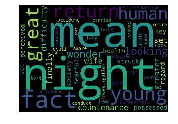

```python
# Generating the wordcloud with the values under the category dataframe
firstcloud = WordCloud(
                          stopwords=STOPWORDS,
                          background_color='black',
                          width=2500,
                          height=1800
                         ).generate(" ".join(first_topic_words))
plt.imshow(firstcloud)
plt.axis('off')
plt.show()
```

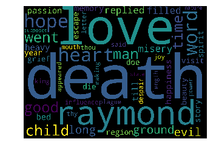

```python
# Generating the wordcloud with the values under the category dataframe
cloud = WordCloud(
                          stopwords=STOPWORDS,
                          background_color='black',
                          width=2500,
                          height=1800
                         ).generate(" ".join(second_topic_words))
plt.imshow(cloud)
plt.axis('off')
plt.show()
```

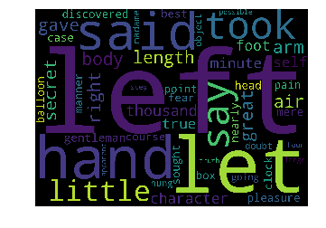

```python
# Generating the wordcloud with the values under the category dataframe
cloud = WordCloud(
                          stopwords=STOPWORDS,
                          background_color='black',
                          width=2500,
                          height=1800
                         ).generate(" ".join(third_topic_words))
plt.imshow(cloud)
plt.axis('off')
plt.show()
```

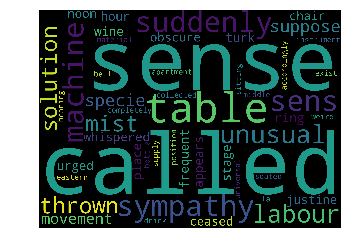

```python
# Generating the wordcloud with the values under the category dataframe
cloud = WordCloud(
                          stopwords=STOPWORDS,
                          background_color='black',
                          width=2500,
                          height=1800
                         ).generate(" ".join(fourth_topic_words))
plt.imshow(cloud)
plt.axis('off')
plt.show()
```

```python
#Posibilidad de visualizar el resultado del LDA gráficamente
import pyLDAvis.sklearn

pyLDAvis.enable_notebook()
panel = pyLDAvis.sklearn.prepare(lda, tf, tf_vectorizer, mds='tsne')
#pyLDAvis.show(panel)
```

**Prueba de crear una frase y transformarla utilizando el modelo LDA para analizar el vector de distribución de topics**

```python
from gensim import similarities
frase1= list(["She loved Raymond to death, yet he left before she could say anything  ."])
print(frase1)
frase1tf = tf_vectorizer.transform(frase1) #Transformo la frase
frase1_lda = lda.transform(frase1tf)
print(frase1_lda)
```

```
['She loved Raymond to death, yet he left before she could say anything  .']
[[0.01515152 0.515151   0.34848363 0.01515152 0.01515152 0.01515204
  0.01515152 0.01515193 0.01515152 0.0151523  0.01515152]]
```

# Similitud entre documentos

Una de las aplicaciónes del modelo LDA es evaluar la similitud entre documentos en base a sus vectores de distribución de topics. Para probar esto, utilizamos la distancia de Hellinger, distancia que se utiliza justamente para medir similitudes entre distribuciones de probabilidad.

Para definir la distancia de Hellinger, llamamos P y Q a dos medidas de probabilidad que son continuas respecto a una tercera medida de proabilidad λ. El cuadrado de la distancia de Hellinger entre P y Q se define como:

[figure not shown]

```python
#Uso hellinger Distance para determinar la similitud entre documentos
import math
from scipy.linalg import norm
from scipy.spatial.distance import euclidean

_SQRT2 = np.sqrt(2)     # sqrt(2) with default precision np.float64

def hellinger3(p, q):
    return np.sqrt(np.sum((np.sqrt(p) - np.sqrt(q)) ** 2)) / _SQRT2


#Formo el vector con las distancias de hellinger
vectordist=[1] * len(lda_Z)
for i in range(len(lda_Z)):
    vectordist[i] = hellinger3(lda_Z[12],lda_Z[i])

index_list =np.argsort(vectordist)

for i in range(10):
    print("Documento numero: ",index_list[i])
    print("Distancia: "vectordist[index_list[i]])
```

[output not shown]

```python
print(text[12])
for i in range(10):
    print("========================================================================")
    print(text[index_list[i]])
```

[output not shown]

# PRUEBA NMF

Una vez analizado el modelo LDA pasamos a implementar el segundo modelo de topic modeling: **Non-Negative Matrix Factorization**

Este método utiliza la matriz de documentos vectorizada, y busca representarla como la multiplicación de dos matrices. Se genera una matriz de components, que corresponden a los topics y una matriz de weights

[figure not shown]

```python
#Creo una clase corresponde al Vectorizador TF-IDF de sklearn con lematización

lemm = WordNetLemmatizer()
class LemmaTFidfVectorizer(TfidfVectorizer):
    def build_analyzer(self):
        analyzer = super(LemmaTFidfVectorizer, self).build_analyzer()
        return lambda doc: (lemm.lemmatize(w) for w in analyzer(doc))
```

```python
#Guardo todo el cuerpo de texto en una lista, donde cada elemento es una oración
texto= list(train.text.values)
print(len(texto),"oraciones o documentos \n")
print(texto[245])
```

```
19579 oraciones o documentos

Many of the vessels fired signal guns; and in all we were saluted with loud cheers which we heard with surprising distinctness and the waving of caps and handkerchiefs.
```

```python
#Instancio el TF-IDF vectorizer con lemmatization
myvectorizer = LemmaTFidfVectorizer(stop_words='english',max_df=0.9,min_df=50,strip_accents='unicode',analyzer='word',use_idf=1,smooth_idf=1)
#Transformo el texto
mytfidf = myvectorizer.fit_transform(texto)
print("Me quedo con una matriz que contiene para cada oracion, los pesos de cada palabra del texto entero en base a su relevancia")
print(mytfidf.shape," de 13781 palabras unicas nos quedamos con 856 ")

#Lista de las features
idx_to_word2 = np.array(myvectorizer.get_feature_names())
print(idx_to_word2[:10])
print(len(idx_to_word2))
```

```
Me quedo con una matriz que contiene para cada oracion, los pesos de cada palabra del texto entero en base a su relevancia
(19579, 856)  de 13781 palabras unicas nos quedamos con 856
['able' 'absence' 'abyss' 'accident' 'account' 'act' 'action' 'actually'
 'added' 'adrian']
856
```

**Pasamos a instanciar y entrenar el modelo de NMF y transformar la matriz TF-IDF**

```python
nmf = NMF(n_components=11, solver="mu")
W= nmf.fit_transform(mytfidf)   # W sería la matriz de componentes
#Acá se pueden ver para cada documento, la distribución de topics
print("Forma de la matriz W:",W.shape,"\n")
print("Primer fila de la matriz W: \n ",W[0])
comp = nmf.components_  # Comp seria la matriz de weights
print("Forma de la matriz H:",comp.shape,"\n")
```

```
Forma de la matriz W: (19579, 11)

Primer fila de la matriz W:
  [0.02799061 0.         0.00241875 0.00011912 0.         0.00596661
 0.         0.00811121 0.         0.         0.        ]
Forma de la matriz H: (11, 856)
```

```python
#imprimo topics
print_top_words(nmf, idx_to_word2, 40)
```

```
Topic #0:like eye great little hand came old house long place left door room year far light head heard word men way voice away street felt friend window earth length wall water hour having mind seen body come strange fear foot
======================================================================

Topic #1:said dupin little let shall friend dear sir know word yes sure raymond adrian mr thousand mean voice altogether quite work matter better spoke fellow speak present coming tone reply dare gentleman degree question companion perdita paper remember island talk
======================================================================

Topic #2:did know come appear understand believe perdita return like mr feel night wish expected look best reason sleep hear companion tell adrian knew think dare mind knowledge wished pas feeling quite west afterward replied fate late asked turn taken wall
======================================================================

Topic #3:thing know world knew earth strange men like tell living unknown wonder told terrible sort horror folk sea fact quite used speak began think read state let seen human impossible ancient tale night hideous ghastly curious object innsmouth simple going
======================================================================

Topic #4:man old god young animal know great dead face seen woman business sat sir terrible small good world black believe follow lived knew read tell appearance genius used tall learned dr music kind person height feared book talk sufficient replied
======================================================================

Topic #5:time long year short mean space spent hour come thousand new know shall soon matter period lost certain manner memory reason think idea make remained interval friend course length sentiment world happy reached past attempt question continued greater mind grief
======================================================================

Topic #6:day night passed came sleep hour late dream following slept arrived morning month come home sun new went journey work early moon gilman grew hill evening spent period london year till dog past continued labour kept rain rise visited returned
======================================================================

Topic #7:say shall course mean point let just truth don little idea make general know true possible question opinion lost strange god impossible dare great think instance come reason article scarcely mind quite dr letter matter speak machine end oh mr
======================================================================

Topic #8:life heart love death shall know hope nature world feeling father friend soul raymond affection word perdita happiness misery spirit human lost mind joy child feel pain die power passion desire happy beauty felt cause existence despair fear dream tear
======================================================================

Topic #9:thought heard dream mind house knew sound second possible really subject moment secret wished mad better endeavoured room sad unknown brain felt present proper sole horror instant idea length fallen visit wish occupied certain faint seen attention sure followed madness
======================================================================

Topic #10:saw eye face light form looked felt tear beheld lip moon stood sight blue foot design fixed expression black countenance looking position feature change wave glance heaven shore attempt car use brow motion length look far turned boat heard smile
======================================================================
```

# Word Cloud de los topics

```python
topic1= comp[0]
print(topic1[:10])
topic2= comp[1]
topic3= comp[2]
topic4= comp[3]
topic5= comp[4]
topic6= comp[5]
topic7= comp[6]
topic8= comp[7]
topic9= comp[8]
topic10= comp[9]
topi11= comp[10]
```

```
[0.06062567 0.056478   0.06017173 0.04381661 0.14350513 0.05067729
 0.07513593 0.04871983 0.05321636 0.09366009]
```

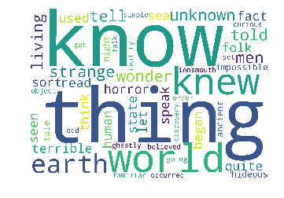

```python
topic4_words = [idx_to_word2[i] for i in topic4.argsort()[:-50 - 1 :-1]] # agarro las primeras 50 palabras en topic 1

nmfcloud4 = WordCloud(
                          stopwords=STOPWORDS,
                          background_color='white',
                          width=2500,
                          height=1800

                         ).generate(" ".join(topic4_words))
plt.imshow(nmfcloud4)
plt.axis('off')
plt.show()
```

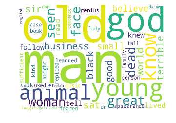

```python
topic5_words = [idx_to_word2[i] for i in topic5.argsort()[:-50 - 1 :-1]] # agarro las primeras 50 palabras en topic 1

nmfcloud5 = WordCloud(
                          stopwords=STOPWORDS,
                          background_color='white',
                          width=2500,
                          height=1800

                         ).generate(" ".join(topic5_words))
plt.imshow(nmfcloud5)
plt.axis('off')
plt.show()
```

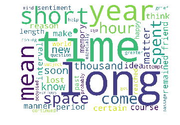

```python
topic6_words = [idx_to_word2[i] for i in topic6.argsort()[:-50 - 1 :-1]] # agarro las primeras 50 palabras en topic 1

nmfcloud6 = WordCloud(
                          stopwords=STOPWORDS,
                          background_color='white',
                          width=2500,
                          height=1800

                         ).generate(" ".join(topic6_words))
plt.imshow(nmfcloud6)
plt.axis('off')
plt.show()
```

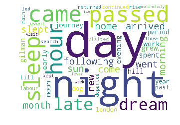

```python
topic7_words = [idx_to_word2[i] for i in topic7.argsort()[:-50 - 1 :-1]] # agarro las primeras 50 palabras en topic 1

nmfcloud7 = WordCloud(
                          stopwords=STOPWORDS,
                          background_color='white',
                          width=2500,
                          height=1800

                         ).generate(" ".join(topic7_words))
plt.imshow(nmfcloud7)
plt.axis('off')
plt.show()
```

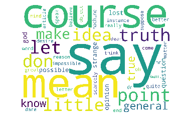

```python
topic8_words = [idx_to_word2[i] for i in topic8.argsort()[:-50 - 1 :-1]] # agarro las primeras 50 palabras en topic 1

nmfcloud8 = WordCloud(
                          stopwords=STOPWORDS,
                          background_color='white',
                          width=2500,
                          height=1800

                         ).generate(" ".join(topic8_words))
plt.imshow(nmfcloud8)
plt.axis('off')
plt.show()
```

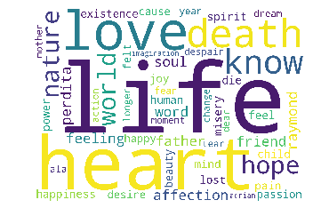

```python
topic9_words = [idx_to_word2[i] for i in topic9.argsort()[:-50 - 1 :-1]] # agarro las primeras 50 palabras en topic 1

nmfcloud9 = WordCloud(
                          stopwords=STOPWORDS,
                          background_color='white',
                          width=2500,
                          height=1800

                         ).generate(" ".join(topic9_words))
plt.imshow(nmfcloud9)
plt.axis('off')
plt.show()
```